# Data Visualization I: Solutions

Below are two alternative plots that are well-suited for displaying categorical x categorical visualizations.

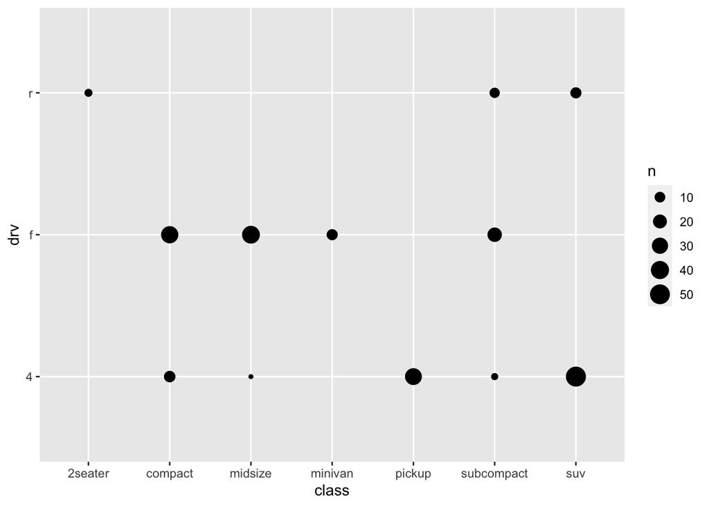

```r
ggplot(mpg, aes(x = class, y = drv)) +
  geom_count()
```

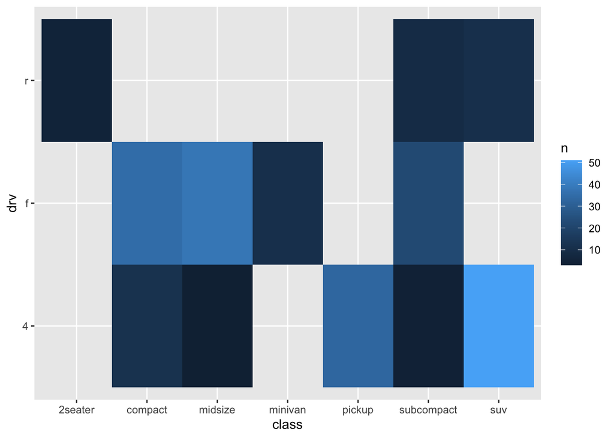

```r
mpg %>%
  count(class, drv) %>%
  ggplot(aes(x = class, y = drv)) +
    geom_tile(mapping = aes(fill = n))
```

4. Which variables in mpg are categorical? Which variables are continuous (Hint: type ?mpg to read the documentation for the dataset). How can you see this information when you run mpg?

The following list contains the categorical variables in mpg:

- manufacturer
- model
- trans
- drv
- fl
- class

The following list contains the continuous variables in mpg:

- displ
- year
- cyl
- cty
- hwy

In the printed tibble, angled brackets at the top of each column provide type of each variable.

```r
mpg
```

```
## # A tibble: 234 × 11
##    manufacturer model      displ  year   cyl trans drv     cty   hwy fl    class
##    <chr>        <chr>      <dbl> <int> <int> <chr> <chr> <int> <int> <chr> <chr>
##  1 audi         a4           1.8  1999     4 auto… f        18    29 p     comp…
##  2 audi         a4           1.8  1999     4 manu… f        21    29 p     comp…
##  3 audi         a4           2    2008     4 manu… f        20    31 p     comp…
##  4 audi         a4           2    2008     4 auto… f        21    30 p     comp…
##  5 audi         a4           2.8  1999     6 auto… f        16    26 p     comp…
##  6 audi         a4           2.8  1999     6 manu… f        18    26 p     comp…
##  7 audi         a4           3.1  2008     6 auto… f        18    27 p     comp…
##  8 audi         a4 quattro   1.8  1999     4 manu… 4        18    26 p     comp…
##  9 audi         a4 quattro   1.8  1999     4 auto… 4        16    25 p     comp…
## 10 audi         a4 quattro   2    2008     4 manu… 4        20    28 p     comp…
## # … with 224 more rows
```

Those with `<chr>` above their columns are categorical, while those with `<dbl>` or `<int>` are continuous.

We could also use the `str` function to evaluate object type

```r
str(mpg)
```

```
## tibble [234 × 11] (S3: tbl_df/tbl/data.frame)
##  $ manufacturer: chr [1:234] "audi" "audi" "audi" "audi" ...
##  $ model       : chr [1:234] "a4" "a4" "a4" "a4" ...
##  $ displ       : num [1:234] 1.8 1.8 2 2 2.8 2.8 3.1 1.8 1.8 2 ...
##  $ year        : int [1:234] 1999 1999 2008 2008 1999 1999 2008 1999 1999 2008 ...
##  $ cyl         : int [1:234] 4 4 4 4 6 6 6 4 4 4 ...
##  $ trans       : chr [1:234] "auto(l5)" "manual(m5)" "manual(m6)" "auto(av)" ...
##  $ drv         : chr [1:234] "f" "f" "f" "f" ...
##  $ cty         : int [1:234] 18 21 20 21 16 18 18 18 16 20 ...
##  $ hwy         : int [1:234] 29 29 31 30 26 26 27 26 25 28 ...
##  $ fl          : chr [1:234] "p" "p" "p" "p" ...
##  $ class       : chr [1:234] "compact" "compact" "compact" "compact" ...
```

Finally, `glimpse` also produces an `str`-like summary of a data frame.

```r
glimpse(mpg)
```

```
## Rows: 234
## Columns: 11
## $ manufacturer <chr> "audi", "audi", "audi", "audi", "audi", "audi", "audi", "…
## $ model        <chr> "a4", "a4", "a4", "a4", "a4", "a4", "a4", "a4 quattro", "…
## $ displ        <dbl> 1.8, 1.8, 2.0, 2.0, 2.8, 2.8, 3.1, 1.8, 1.8, 2.0, 2.0, 2.…
## $ year         <int> 1999, 1999, 2008, 2008, 1999, 1999, 2008, 1999, 1999, 200…
## $ cyl          <int> 4, 4, 4, 4, 6, 6, 6, 4, 4, 4, 4, 6, 6, 6, 6, 6, 6, 8, 8, …
## $ trans        <chr> "auto(l5)", "manual(m5)", "manual(m6)", "auto(av)", "auto…
## $ drv          <chr> "f", "f", "f", "f", "f", "f", "f", "4", "4", "4", "4", "4…
## $ cty          <int> 18, 21, 20, 21, 16, 18, 18, 18, 16, 20, 19, 15, 17, 17, 1…
## $ hwy          <int> 29, 29, 31, 30, 26, 26, 27, 26, 25, 28, 27, 25, 25, 25, 2…
## $ fl           <chr> "p", "p", "p", "p", "p", "p", "p", "p", "p", "p", "p", "p…
## $ class        <chr> "compact", "compact", "compact", "compact", "compact", "c…
```

5. What happens if you map an aesthetic to something other than a variable name, like `aes(color = displ < 5)` 6. What happens if you facet on a continuous variable?

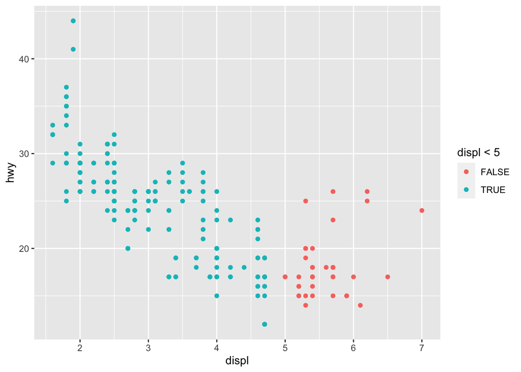

```r
ggplot(mpg, aes(x = displ, y = hwy, colour = displ < 5)) +
  geom_point()
```

Aesthetics can also be mapped to expressions like `displ < 5`. The `ggplot()` function behaves as if a temporary variable was added to the data with values equal to the result of the expression. In this case, the result of `displ < 5` is a logical variable which takes values of `TRUE` or `FALSE`.

6. What happens if you facet on a continuous variable?

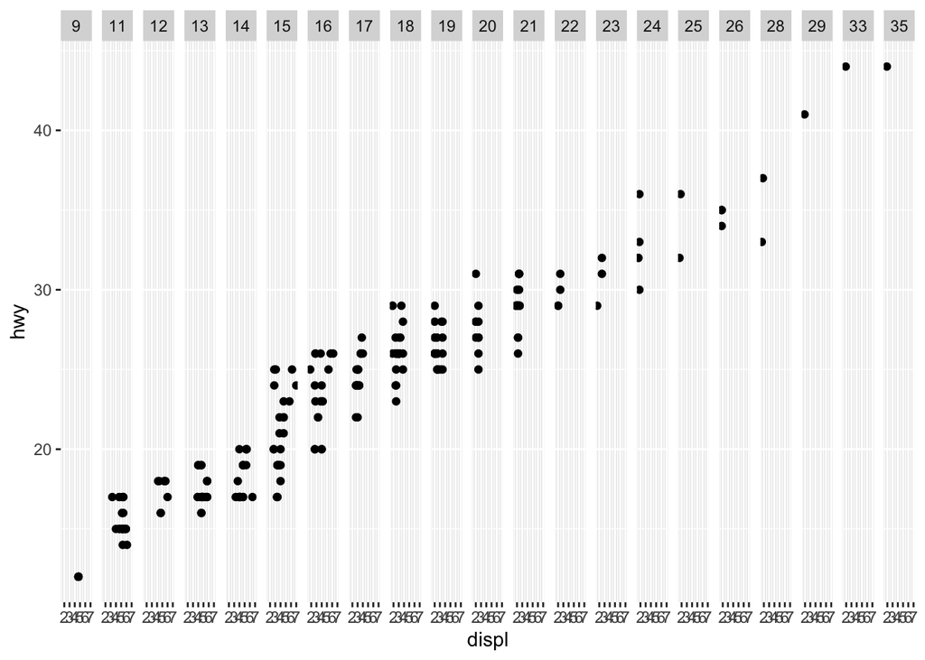

```r
ggplot(mpg, aes(x = displ, y = hwy)) +
  geom_point() +
  facet_grid(. ~ cty)
```

The continuous variable is converted to a categorical variable, and the plot contains a facet for each distinct value.

7. What do the empty cells in a plot with `facet_grid(drv~cyl)` mean? How do they relate to this plot?  
`ggplot(data = mpg) + geom_point(aes(x = drv, y = cyl)) <br>`

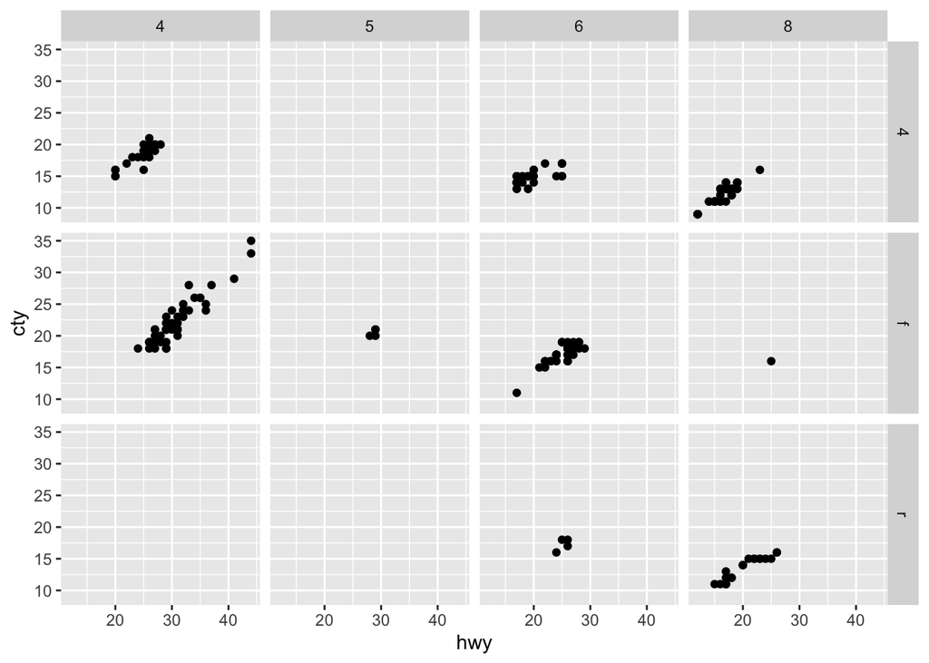

```r
ggplot(data = mpg) +
  geom_point(mapping = aes(x = hwy, y = cty)) +
  facet_grid(drv ~ cyl)
```

The empty cells (facets) in this plot are combinations of `drv` and `cyl` that have no observations. These are the same locations in the scatter plot of `drv` and `cyl` that have no points.

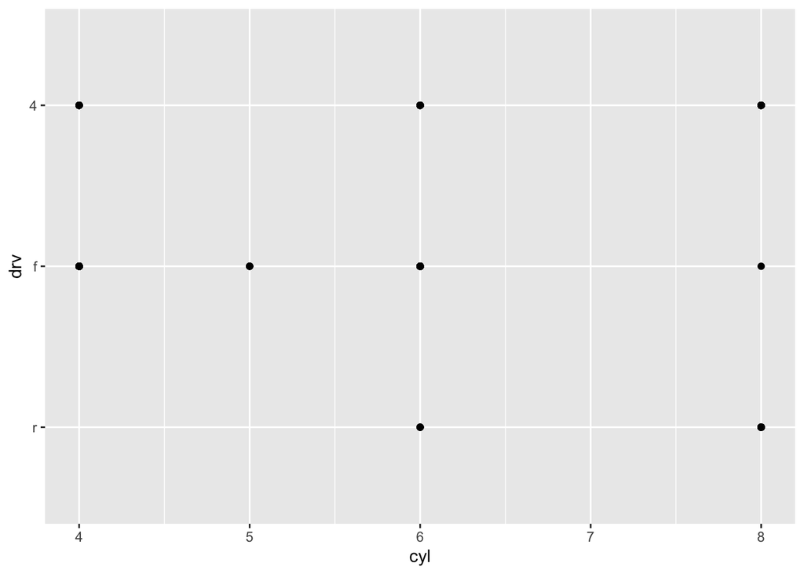

```r
ggplot(data = mpg) +
  geom_point(mapping = aes(x = cyl, y = drv)) +
  scale_y_discrete(limits = rev)
```

8. What geom would you use to draw a line chart? A boxplot? A histogram? An area chart?

- line chart: `geom_line()`
- boxplot: `geom_boxplot()`
- histogram: `geom_histogram()`
- area chart: `geom_area()`

9. What does `show.legend = FALSE` do? What happens if you remove it?

The theme option `show.legend = FALSE` hides the legend box.

Consider this example earlier in the chapter.

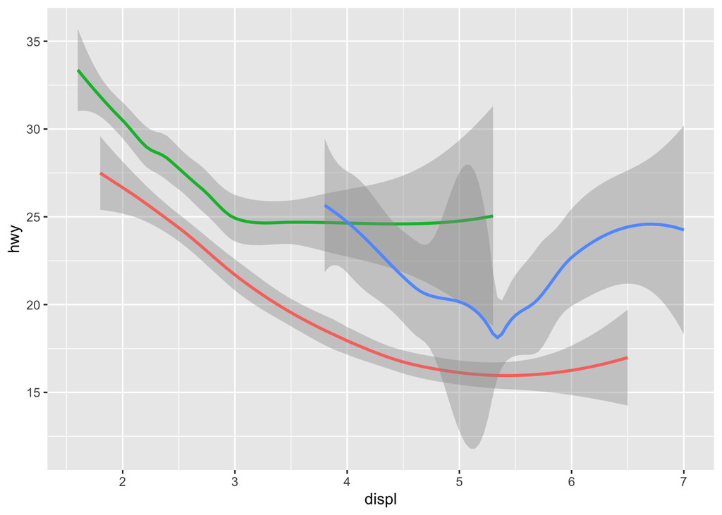

```r
ggplot(data = mpg) +
  geom_smooth(
    mapping = aes(x = displ, y = hwy, colour = drv),
    show.legend = FALSE
  )
```

In that plot, there is no legend. Removing the `show.legend` argument or setting `show.legend = TRUE` will result in the plot having a legend displaying the mapping between colors and `drv`.

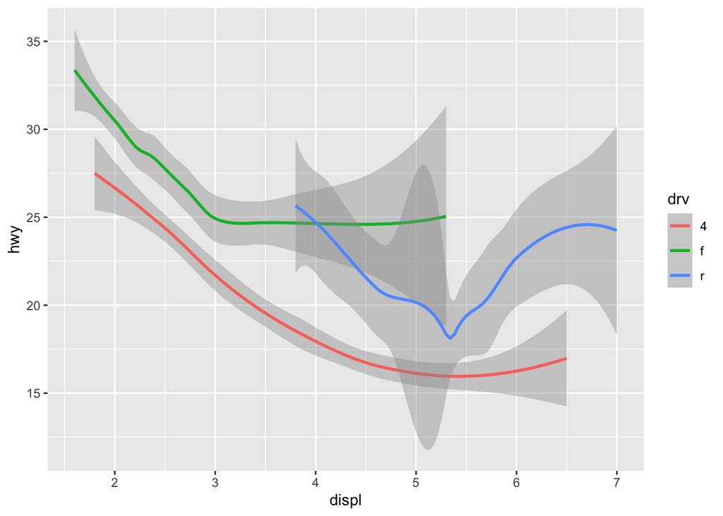

```r
ggplot(data = mpg) +
  geom_smooth(mapping = aes(x = displ, y = hwy, colour = drv))
```

10. What does `geom_col` do? How is it different from `geom_bar`?

The `geom_col()` function has different default stat than `geom_bar()`. The default stat of `geom_col()` is `stat_identity()`, which leaves the data as is. The `geom_col()` function expects that the data contains `x` values and `y` values which represent the bar height.

The default stat of `geom_bar()` is `stat_count()`. The `geom_bar()` function only expects an `x` variable. The stat, `stat_count()`, preprocesses input data by counting the number of observations for each value of `x`. The `y` aesthetic uses the values of these counts.

11. What is the problem with this plot? How could you improve it?

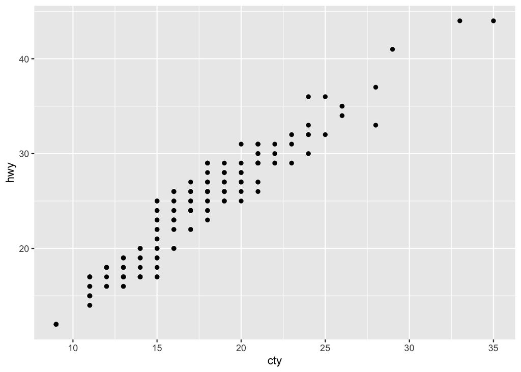

```r
ggplot(data = mpg, mapping = aes(x = cty, y = hwy)) +
  geom_point()
```

There is overplotting because there are multiple observations for each combination of `cty` and `hwy` values.

I would improve the plot by using a jitter position adjustment to decrease overplotting.

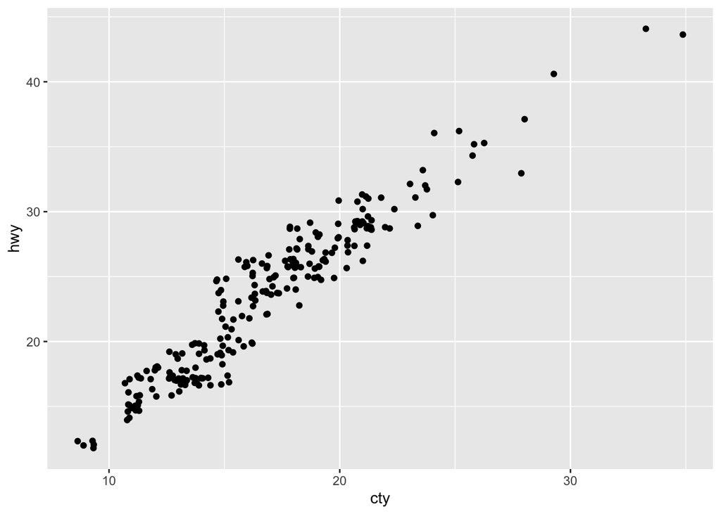

```r
ggplot(data = mpg, mapping = aes(x = cty, y = hwy)) +
  geom_point(position = "jitter")
```

13. What parameters to `geom_jitter` control the amount of jittering?

From the [`geom_jitter()`](https://ggplot2.tidyverse.org/reference/geom_jitter.html) documentation, there are two arguments to jitter:

- `width` controls the amount of horizontal displacement, and
- `height` controls the amount of vertical displacement.

The defaults values of `width` and `height` will introduce noise in both directions. Here is what the plot looks like with the default values of `height` and `width`.

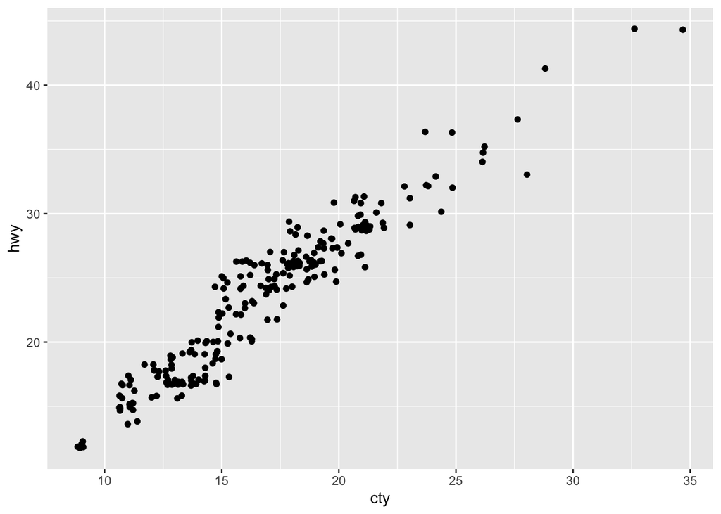

```r
ggplot(data = mpg, mapping = aes(x = cty, y = hwy)) +
  geom_point(position = position_jitter())
```

However, we can change these parameters. Here are few a examples to understand how these parameters affect the amount of jittering. When`width = 0` there is no horizontal jitter.

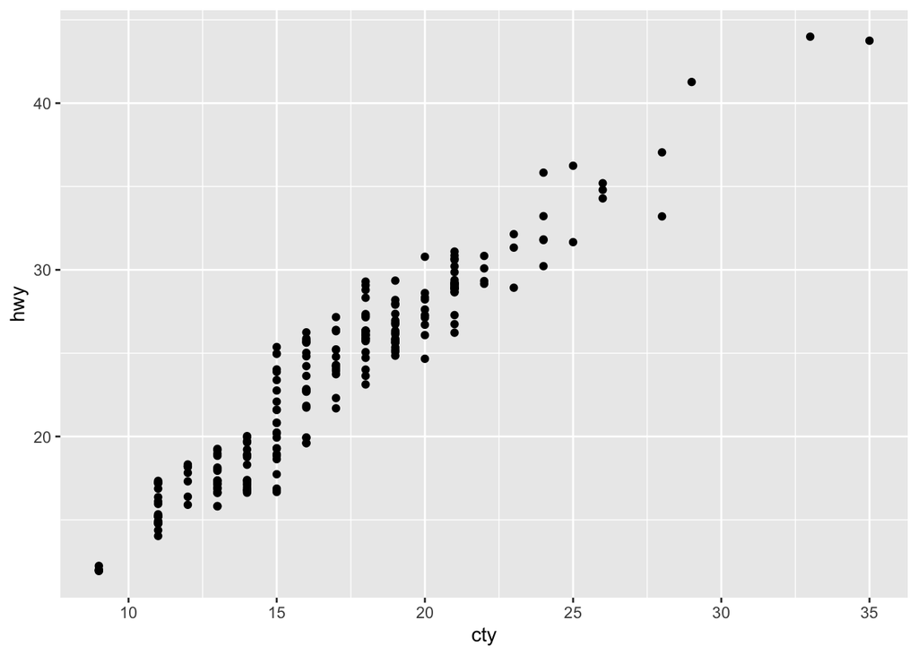

```r
ggplot(data = mpg, mapping = aes(x = cty, y = hwy)) +
  geom_jitter(width = 0)
```

When `width = 20`, there is too much horizontal jitter.

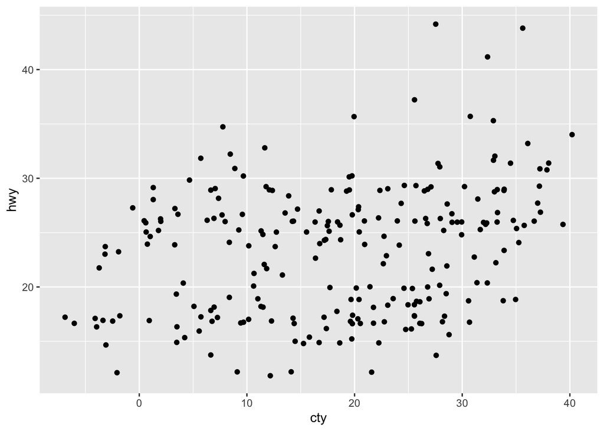

```r
ggplot(data = mpg, mapping = aes(x = cty, y = hwy)) +
  geom_jitter(width = 20)
```

When `height = 0`, there is no vertical jitter.

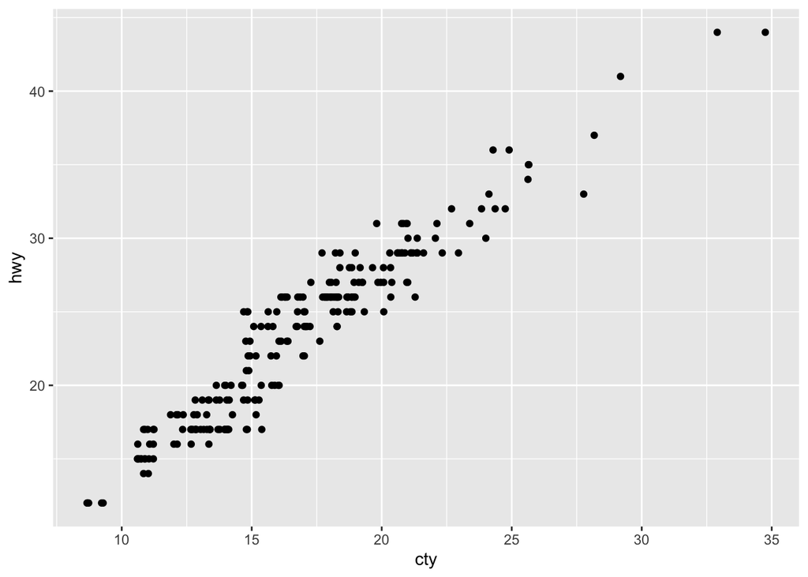

```r
ggplot(data = mpg, mapping = aes(x = cty, y = hwy)) +
  geom_jitter(height = 0)
```

When `height = 15`, there is too much vertical jitter.

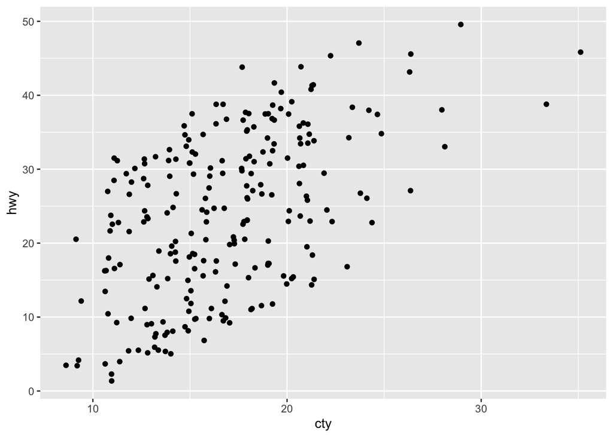

```r
ggplot(data = mpg, mapping = aes(x = cty, y = hwy)) +
  geom_jitter(height = 15)
```

When `width = 0` and `height = 0`, there is neither horizontal or vertical jitter, and the plot produced is identical to the one produced with `geom_point()`

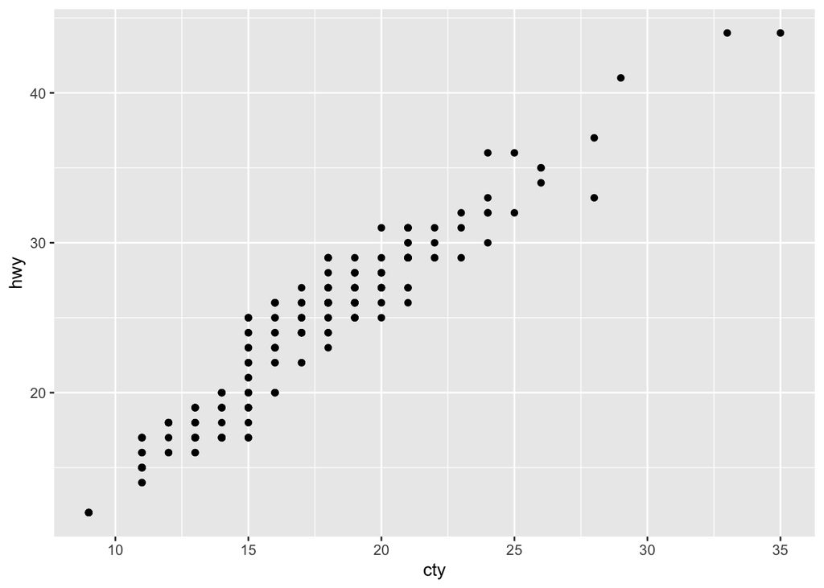

```r
ggplot(data = mpg, mapping = aes(x = cty, y = hwy)) +
  geom_jitter(height = 0, width = 0)
```

Note that the `height` and `width` arguments are in the units of the data. Thus `height = 1` (`width = 1`) corresponds to different relative amounts of jittering depending on the scale of the `y` (`x`) variable. The default values of `height` and `width` are defined to be 80% of the `resolution()` of the data, which is the smallest non-zero distance between adjacent values of a variable. When `x` and `y` are discrete variables, their resolutions are both equal to 1, and `height = 0.4` and `width = 0.4` since the jitter moves points in both positive and negative directions.

The default values of `height` and `width` in `geom_jitter()` are non-zero, so unless both `height` and `width` are explicitly set set 0, there will be some jitter.

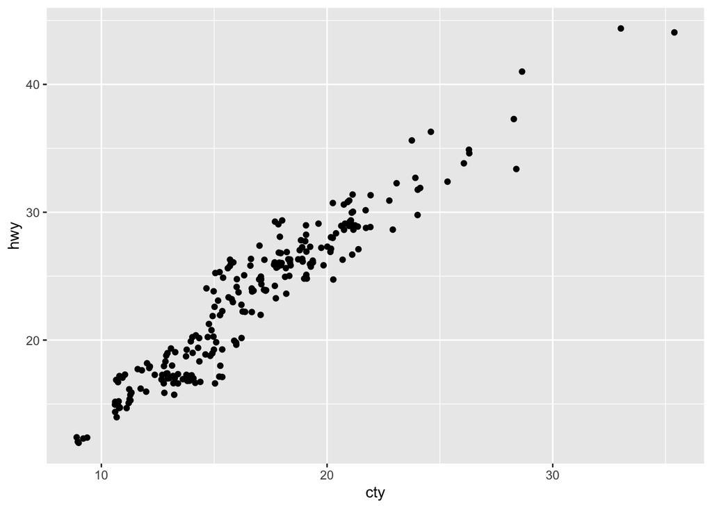

```r
ggplot(data = mpg, mapping = aes(x = cty, y = hwy)) +
  geom_jitter()
```